# Delhi PM2.5 Analysis (2022)

Darakhshan Nehal

# Introduction

Particulate matter smaller than 2.5 micrometres (PM2.5) is among the most dangerous air pollutants — fine enough to penetrate deep into lung tissue and enter the bloodstream, causing cardiovascular and respiratory disease. Delhi consistently ranks among the most polluted megacities in the world, with winter months (October–January) seeing PM2.5 concentrations that routinely exceed WHO safe limits by a factor of 10 or more.

This vignette demonstrates how the `vayuayan` package integrates two independent data sources to analyse Delhi’s air quality in 2022, and uses them together to answer a key policy question:

We build toward this answer in four steps:

# Data & Methods

## Satellite Data

Monthly PM2.5 estimates come from the Washington University in St. Louis Atmospheric Composition Analysis Group (WUSTL ACAG) **V5GL04** product — a globally gridded dataset at ~0.01° (~1 km) resolution, derived from satellite aerosol optical depth retrievals, chemical transport modelling, and ground-level calibration (van Donkelaar et al., 2021). Files are in NetCDF format.

> **Note:** V5GL04 covers 1998–2022. Data for 2023 onward requires V6GL02, which is pending download on the departmental server. This vignette uses 2022 throughout.

## Ground Data

Daily city-level and per-station PM2.5 readings are fetched from the Central Pollution Control Board (CPCB) data repository using `cpcb_download_city_data()` and `cpcb_download_station_data()`. Delhi has 46 operational Continuous Ambient Air Quality Monitoring Stations (CAAQMS) managed by DPCC, CPCB, IMD, and IITM. Station coordinates are obtained via `cpcb_add_coords()`, which queries the CPCB live feed directly. Nominatim is used as a fallback only for stations temporarily absent from the live feed.

## Spatial Units

Ward boundaries are from the **BharatViz** Delhi ward dataset (`delhi_bharat_viz_wards.geojson`) — 290 wards with full Delhi coverage including the New Delhi Municipal Council (NDMC) area, sourced from `bharatviz.saketlab.org`. This single boundary file is used for all spatial analyses in this vignette.

## Comparison Caveat

These two data sources measure PM2.5 differently:

- **Satellite** = spatial mean over an entire area (~1 km pixels)
- **Ground** = point measurement at one physical location, often sited near pollution sources

Ground readings are therefore consistently higher than satellite estimates. This is not an error — it reflects the fundamental difference between point-source and area-averaged measurement. Ground data is aggregated to monthly means for fair temporal comparison.

# Setup

```r
if (!require("pacman", quietly = TRUE)) {
  install.packages("pacman", repos = "https://cloud.r-project.org")
}

pacman::p_load(
  vayuayan,      # CPCB data download + geocoding
  tidyverse,     # data wrangling + ggplot2
  purrr,         # map_dfr for iterating over months
  terra,         # raster operations
  sf,            # vector spatial data
  tidyterra,     # ggplot2 + terra integration (geom_spatraster)
  exactextractr, # area-weighted raster extraction to polygons
  ncdf4,         # reading NetCDF files directly
  khroma,        # diverging colour palettes
  stringr        # string cleaning
)
```

```r
# Absolute path — works both interactively and when knitting
vignettes_dir <- "/NAS/darakshann/vayuayanR/vignettes"

dirs <- c("data/delhi", "figures/delhi", "station_data")
for (d in dirs) dir.create(file.path(vignettes_dir, d),
                            recursive = TRUE, showWarnings = FALSE)

data_path    <- function(f) file.path(vignettes_dir, "data/delhi",    f)
fig_path     <- function(f) file.path(vignettes_dir, "figures/delhi", f)
station_path <- function(f) file.path(vignettes_dir, "station_data",  f)
```

## Helper Functions

The V5GL04 NetCDF files store data in `[lon, lat]` order — the reverse of what `terra` expects (`[lat, lon]`). Loading the entire 121 MB global array just to extract Delhi is extremely slow. These two helpers read only the pixels covering Delhi’s bounding box, making extraction near-instant.

```r
read_v5gl04_fast <- function(nc_path, shape) {
  bbox    <- sf::st_bbox(shape)
  nc      <- ncdf4::nc_open(nc_path)
  lons    <- ncdf4::ncvar_get(nc, "lon")
  lats    <- ncdf4::ncvar_get(nc, "lat")
  lon_idx <- which(lons >= bbox["xmin"] & lons <= bbox["xmax"])
  lat_idx <- which(lats >= bbox["ymin"] & lats <= bbox["ymax"])
  data    <- ncdf4::ncvar_get(
    nc, "GWRPM25",
    start = c(min(lon_idx), min(lat_idx)),
    count = c(length(lon_idx), length(lat_idx))
  )
  ncdf4::nc_close(nc)
  mean(data, na.rm = TRUE)
}

load_v5gl04_rast <- function(year, month, shape) {
  nc_path <- sprintf(
    "/NAS/climatehealth/WUSTL_PM2.5/V5GL04/Global/Monthly/V5GL04.HybridPM25.Global.%04d%02d-%04d%02d.nc",
    year, month, year, month
  )
  bbox    <- sf::st_bbox(shape)
  nc      <- ncdf4::nc_open(nc_path)
  lons    <- ncdf4::ncvar_get(nc, "lon")
  lats    <- ncdf4::ncvar_get(nc, "lat")
  lon_idx <- which(lons >= bbox["xmin"] & lons <= bbox["xmax"])
  lat_idx <- which(lats >= bbox["ymin"] & lats <= bbox["ymax"])
  data    <- ncdf4::ncvar_get(
    nc, "GWRPM25",
    start = c(min(lon_idx), min(lat_idx)),
    count = c(length(lon_idx), length(lat_idx))
  )
  ncdf4::nc_close(nc)
  r <- terra::rast(
    nrows = length(lat_idx), ncols = length(lon_idx),
    xmin  = min(lons[lon_idx]), xmax = max(lons[lon_idx]),
    ymin  = min(lats[lat_idx]), ymax = max(lats[lat_idx]),
    crs   = "EPSG:4326"
  )
  terra::values(r) <- t(data)[nrow(t(data)):1, ]
  r
}
```

# Results

## 1. Seasonal Trend: Do Satellite and Ground Data Agree?

### Ground Data: City-Level Monthly PM2.5

```r
if (!file.exists(data_path("delhi_aqi_2022.csv"))) {
  cpcb_download_city_data(
    city          = "Delhi",
    year          = 2022,
    save_location = data_path("delhi_aqi_2022.csv")
  )
}

delhi_wide <- read.csv(data_path("delhi_aqi_2022.csv"))

delhi_ground <- delhi_wide %>%
  pivot_longer(cols = -Day, names_to = "Month_Name", values_to = "ground_pm25") %>%
  mutate(month = match(Month_Name, month.name)) %>%
  filter(!is.na(ground_pm25)) %>%
  group_by(month) %>%
  summarise(ground_pm25 = mean(ground_pm25, na.rm = TRUE), .groups = "drop")

print(delhi_ground)
```

```
#> # A tibble: 12 × 2
#>    month ground_pm25
#>    <int>       <dbl>
#>  1     1       279.
#>  2     2       225.
#>  3     3       217.
#>  4     4       255.
#>  5     5       212.
#>  6     6       190.
#>  7     7        87.4
#>  8     8        93.4
#>  9     9       104.
#> 10    10       210.
#> 11    11       321.
#> 12    12       319.
```

### Satellite Data: Monthly Spatial Mean over Delhi

```r
# Load BharatViz ward boundary — single boundary used throughout this vignette
delhi_shape <- sf::st_read(
  "/NAS/darakshann/geojson/delhi_bharat_viz_wards.geojson", quiet = TRUE
) %>% sf::st_make_valid()

delhi_sat_df <- map_dfr(1:12, function(m) {
  nc_file <- sprintf(
    "/NAS/climatehealth/WUSTL_PM2.5/V5GL04/Global/Monthly/V5GL04.HybridPM25.Global.2022%02d-2022%02d.nc",
    m, m
  )
  tibble(month = m, sat_pm25 = read_v5gl04_fast(nc_file, delhi_shape))
})

delhi_final <- inner_join(delhi_ground, delhi_sat_df, by = "month")
print(delhi_final)
```

```
#> # A tibble: 12 × 3
#>    month ground_pm25 sat_pm25
#>    <int>       <dbl>    <dbl>
#>  1     1       279.     150.
#>  2     2       225.     114.
#>  3     3       217.     108.
#>  4     4       255.      97.9
#>  5     5       212.      78.4
#>  6     6       190.      71.4
#>  7     7        87.4     36.1
#>  8     8        93.4     35.6
#>  9     9       104.      37.5
#> 10    10       210.      72.7
#> 11    11       321.     167.
#> 12    12       319.     176.
```

### Seasonal Line Chart

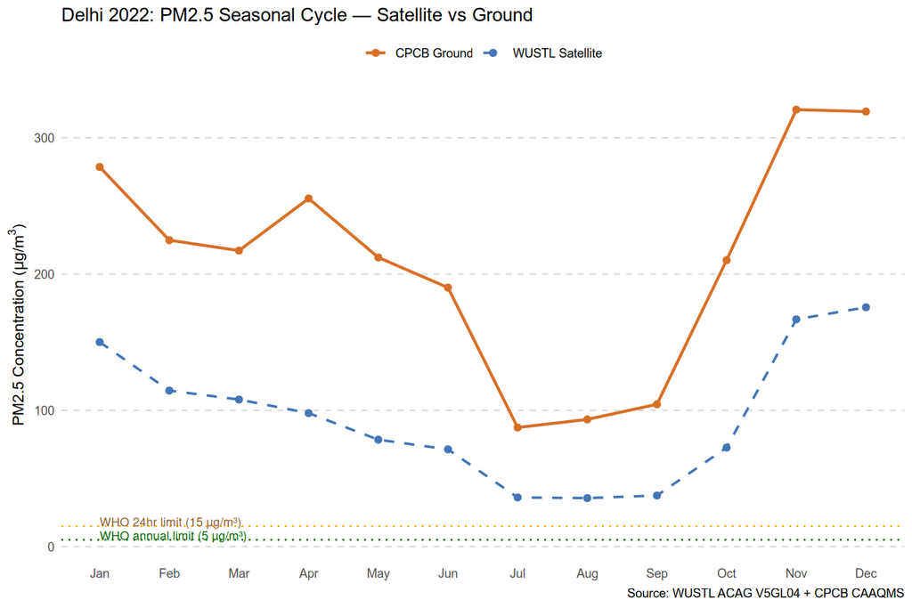

Delhi 2022: Monthly PM2.5 from satellite and ground sources. Both sources agree on the seasonal pattern — peak in winter, trough in monsoon. Ground readings are consistently higher due to the point-to-area measurement difference.

```r
ggplot(delhi_final, aes(x = month)) +
  geom_line(aes(y = ground_pm25, color = "CPCB Ground"), linewidth = 1) +
  geom_line(aes(y = sat_pm25, color = "WUSTL Satellite"),
            linewidth = 0.85, linetype = "dashed") +
  geom_point(aes(y = ground_pm25, color = "CPCB Ground"), size = 2) +
  geom_point(aes(y = sat_pm25,    color = "WUSTL Satellite"), size = 2) +
  geom_hline(yintercept = 5,  linetype = "dotted", color = "darkgreen", linewidth = 0.6) +
  geom_hline(yintercept = 15, linetype = "dotted", color = "orange",    linewidth = 0.6) +
  annotate("text", x = 1, y = 18, label = "WHO 24hr limit (15 µg/m³)",
           size = 3, color = "tan4", hjust = 0) +
  annotate("text", x = 1, y = 8,  label = "WHO annual limit (5 µg/m³)",
           size = 3, color = "darkgreen", hjust = 0) +
  scale_x_continuous(breaks = 1:12, labels = month.abb) +
  scale_color_manual(values = c(
    "CPCB Ground"     = "#d77027ff",
    "WUSTL Satellite" = "#4575b4"
  )) +
  labs(
    title   = "Delhi 2022: PM2.5 Seasonal Cycle — Satellite vs Ground",
    y       = expression(paste("PM2.5 Concentration (", mu, "g/m"^3, ")")),
    x       = NULL,
    color   = NULL,
    caption = "Source: WUSTL ACAG V5GL04 + CPCB CAAQMS"
  ) +
  theme_minimal(base_size = 11) +
  theme(
    text               = element_text(family = "Arial"),
    panel.grid.major.x = element_blank(),
    panel.grid.minor   = element_blank(),
    panel.grid.major.y = element_line(linetype = "dashed", color = "grey85"),
    legend.position    = "top"
  )
```

```r
ggsave(fig_path("fig1_seasonal_trend.png"), width = 9, height = 6, dpi = 300)
```

> **Note:** For 2023–2025, ground data is available but satellite data (V6GL02) is pending download on the departmental server.

## 2. Where Is Pollution Highest? Spatial Heatmap

```r
r_nov               <- load_v5gl04_rast(2022, 11, delhi_shape)
delhi_raster_mask   <- terra::mask(r_nov, terra::vect(delhi_shape))
delhi_city_boundary <- sf::st_union(delhi_shape)
```

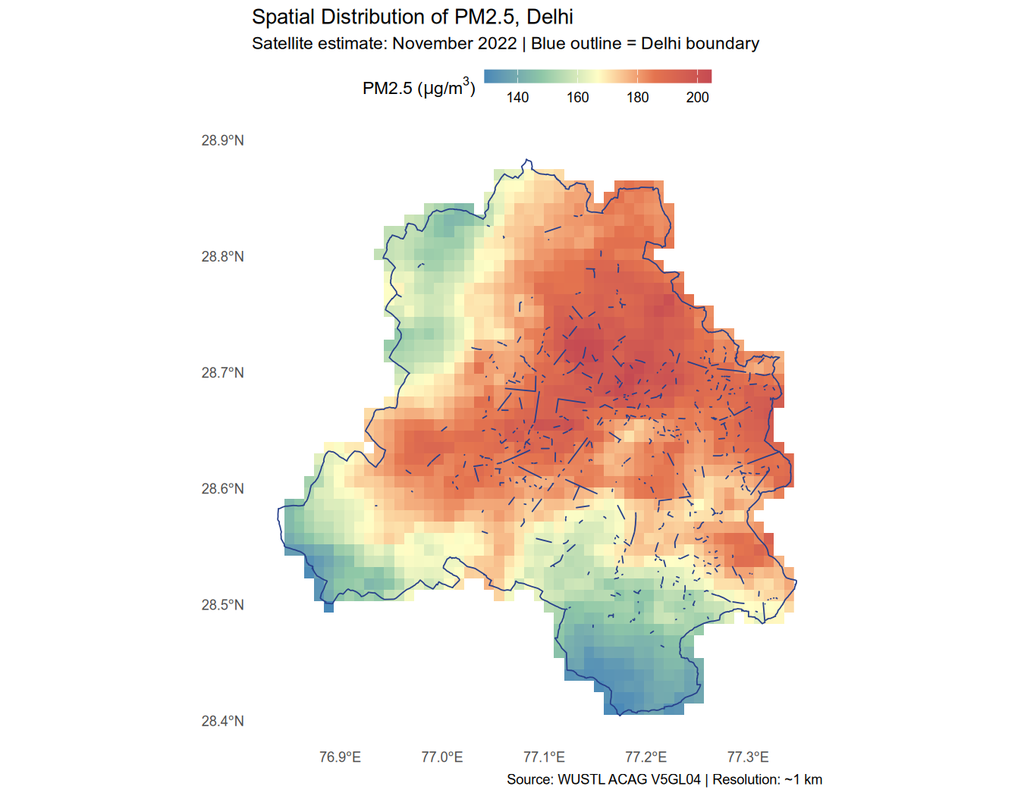

```r
ggplot() +
  geom_spatraster(data = delhi_raster_mask) +
  geom_sf(
    data      = delhi_city_boundary,
    fill      = NA,
    color     = "royalblue4",
    linewidth = 0.4
  ) +
  scale_fill_whitebox_c(
    palette = "muted",
    name    = expression(paste("PM2.5 (", mu, "g/m"^3, ")"))
  ) +
  labs(
    title    = "Spatial Distribution of PM2.5, Delhi",
    subtitle = "Satellite estimate: November 2022 | Blue outline = Delhi boundary",
    caption  = "Source: WUSTL ACAG V5GL04 | Resolution: ~1 km"
  ) +
  xlab(NULL) + ylab(NULL) +
  theme_minimal(base_size = 11) +
  theme(
    text             = element_text(family = "Arial"),
    panel.grid.major = element_blank(),
    panel.grid.minor = element_blank(),
    legend.position  = "top"
  ) +
  guides(fill = guide_colorbar(
    barwidth  = unit(10, "lines"),
    barheight = unit(0.6, "lines")
  ))
```

```r
ggsave(fig_path("fig2_heatmap_nov2022.png"), width = 8, height = 6, dpi = 300)
```

## 3. Where Are the Sensors? Station Network Choropleth

### Load and Geocode Station Locations

```r
if (file.exists(data_path("delhi_stations_with_coords.csv"))) {
  delhi_station_list <- read.csv(data_path("delhi_stations_with_coords.csv"))
} else {
  delhi_station_list <- cpcb_get_station_list("Delhi")
  delhi_station_list <- cpcb_add_coords(delhi_station_list)
  write.csv(delhi_station_list, data_path("delhi_stations_with_coords.csv"),
            row.names = FALSE)
}

delhi_full_sf <- delhi_station_list %>%
  filter(!is.na(lat)) %>%
  sf::st_as_sf(coords = c("lon", "lat"), crs = 4326)

cat(nrow(delhi_full_sf), "stations loaded\n")
```

```
#> 47 stations loaded
```

### Choropleth: Ward-Level PM2.5 + Station Locations

```r
# delhi_shape already loaded above — 290 BharatViz wards, full Delhi coverage
# Compute area-weighted mean satellite PM2.5 per ward
delhi_wards <- delhi_shape
delhi_wards$sat_pm25 <- exactextractr::exact_extract(
  r_nov, delhi_wards, 'mean', progress = FALSE
)
```

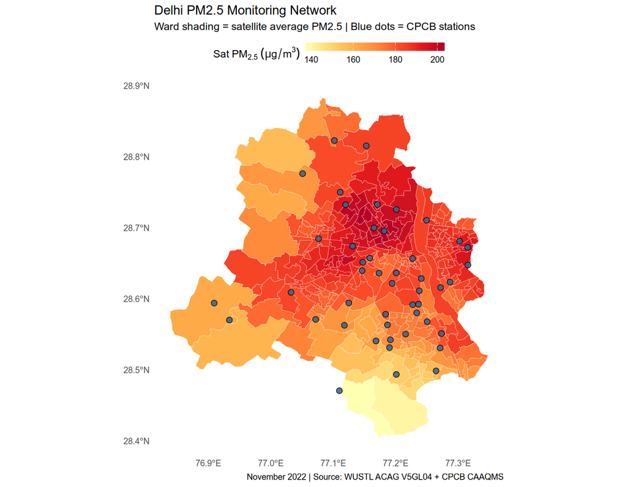

Ward-level satellite PM2.5 with CPCB station locations. Stations cluster in central Delhi; several peripheral wards with elevated PM2.5 are poorly served by the current network.

```r
ggplot() +
  geom_sf(
    data = delhi_wards, aes(fill = sat_pm25),
    color = "white", linewidth = 0.1
  ) +
  geom_sf(
    data  = delhi_full_sf, color = "black",
    fill  = "steelblue4", size = 2.5, shape = 21, alpha = 0.85
  ) +
  scale_fill_distiller(
    palette   = "YlOrRd",
    direction = 1,
    na.value  = "grey80",
    name      = expression(paste("Sat PM"[2.5] ~ (mu * g/m^3)))
  ) +
  labs(
    title    = "Delhi PM2.5 Monitoring Network",
    subtitle = "Ward shading = satellite average PM2.5 | Blue dots = CPCB stations",
    caption  = "November 2022 | Source: WUSTL ACAG V5GL04 + CPCB CAAQMS"
  ) +
  xlab(NULL) + ylab(NULL) +
  theme_minimal(base_size = 11) +
  theme(
    text             = element_text(family = "Arial"),
    panel.grid.major = element_blank(),
    panel.grid.minor = element_blank(),
    legend.position  = "top"
  ) +
  guides(fill = guide_colorbar(
    barwidth  = unit(10, "lines"),
    barheight = unit(0.6, "lines")
  ))
```

```r
ggsave(fig_path("fig3_choropleth_stations.png"), width = 9, height = 7, dpi = 300)
```

> **Key finding:** Stations cluster in central and south Delhi. Several peripheral wards with relatively high PM2.5 have sparse or no nearby sensor coverage.

## 4. Monitoring Gap Analysis

We now answer the central question: **which wards are under-monitored, and does sensor distance predict ground-satellite disagreement?**

### Concept

For each of the **290 BharatViz wards** we:

1. Find its geographic centroid
2. Identify the nearest CPCB station and its winter ground PM2.5 reading
3. Extract satellite PM2.5 at that centroid
4. Compute **delta = satellite − nearest ground station**
5. Draw a line connecting centroid → nearest station

### Per-Station Winter Ground Data

```r
station_raw <- lapply(seq_along(delhi_station_list$value), function(i) {
  id   <- delhi_station_list$value[i]
  file <- station_path(paste0(id, ".csv"))

  tryCatch({
    if (!file.exists(file)) {
      cpcb_download_station_data(
        station_id    = id,
        year          = 2022,
        save_location = file
      )
    }
    df      <- read.csv(file)
    day_col <- names(df)[1]

    df %>%
      pivot_longer(cols      = -all_of(day_col),
                   names_to  = "Month_Name",
                   values_to = "pm25") %>%
      mutate(month = match(Month_Name, month.name)) %>%
      filter(month %in% c(1, 10, 11, 12), !is.na(pm25)) %>%
      summarise(ground_pm25 = mean(pm25, na.rm = TRUE)) %>%
      mutate(value = id)

  }, error = function(e) {
    message("Skipped: ", id)
    data.frame(value = id, ground_pm25 = NA)
  })
})

station_ground <- do.call(rbind, station_raw)

station_ground_sf <- station_ground %>%
  filter(!is.na(ground_pm25)) %>%
  left_join(delhi_station_list %>% select(value, lat, lon), by = "value") %>%
  filter(!is.na(lat), !is.na(lon)) %>%
  sf::st_as_sf(coords = c("lon", "lat"), crs = 4326)

cat(nrow(station_ground_sf), "stations with valid winter PM2.5\n")
```

```
#> 39 stations with valid winter PM2.5
```

### Compute Delta at Each Ward Centroid

```r
ward_centroids <- sf::st_centroid(delhi_wards)

sat_centroid_vals              <- terra::extract(r_nov, terra::vect(ward_centroids))
delhi_wards[["sat_pm25_centroid"]] <- sat_centroid_vals[["lyr.1"]]

dist_matrix_winter <- sf::st_distance(ward_centroids, station_ground_sf)
nearest_idx        <- apply(dist_matrix_winter, 1, which.min)

delhi_wards$nearest_ground_pm25 <- station_ground_sf$ground_pm25[nearest_idx]
delhi_wards$nearest_winter_km   <- apply(dist_matrix_winter, 1, min) / 1000
delhi_wards$delta               <- delhi_wards$sat_pm25_centroid -
                                   delhi_wards$nearest_ground_pm25

delhi_wards <- delhi_wards %>%
  mutate(
    priority = case_when(
      nearest_winter_km > 2 &
        sat_pm25_centroid > median(sat_pm25_centroid, na.rm = TRUE) ~ "High priority",
      nearest_winter_km > 2                                          ~ "Medium priority",
      TRUE                                                            ~ "Well monitored"
    )
  )

cat("Delta summary (satellite - nearest ground station):\n")
```

```
#> Delta summary (satellite - nearest ground station):
```

```r
print(summary(delhi_wards$delta))
```

```
#>    Min. 1st Qu.  Median    Mean 3rd Qu.    Max.
#> -162.45 -121.71 -109.28 -108.36  -98.27  -35.32
```

```r
cat("\nPriority breakdown:\n")
```

```
#>
#> Priority breakdown:
```

```r
print(table(delhi_wards$priority))
```

```
#>
#>   High priority Medium priority  Well monitored
#>              86              81             123
```

### The Monitoring Gap Map

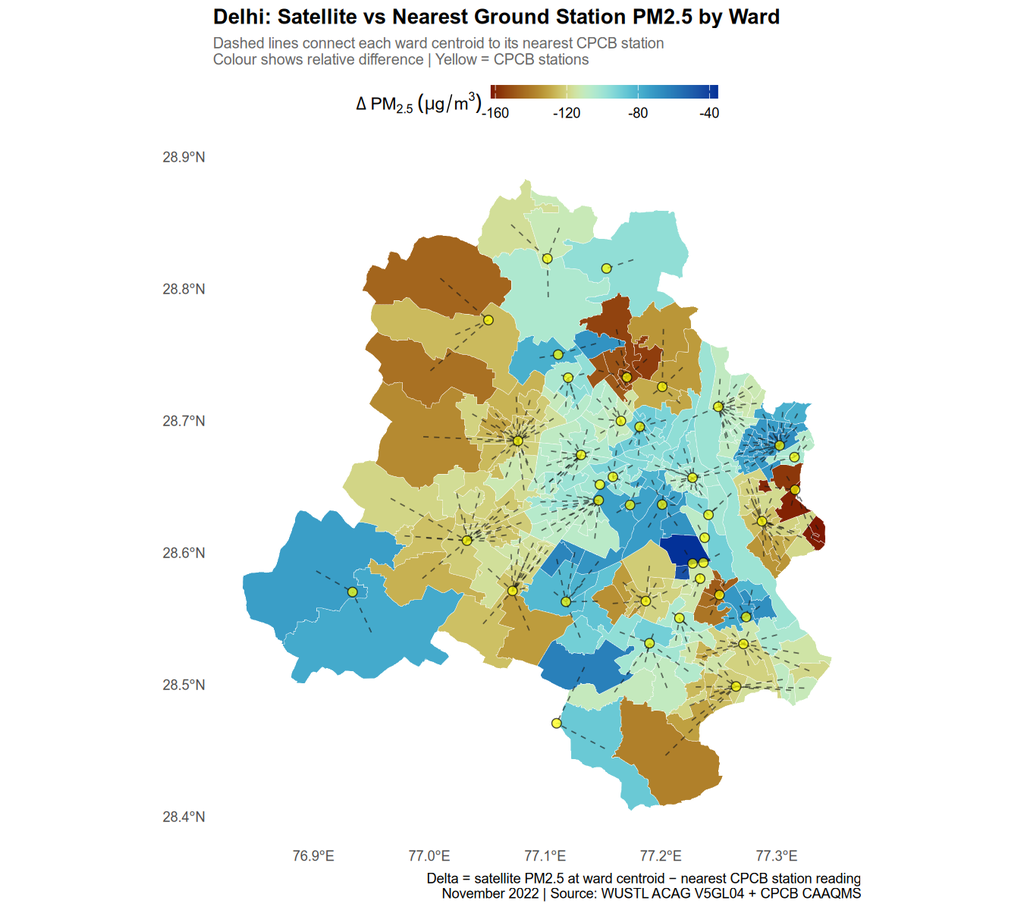

Monitoring gap map. Each ward is coloured by ground-satellite disagreement. Dashed lines connect each ward centroid to its nearest CPCB station. Yellow dots = CPCB stations.

```r
centroid_coords <- sf::st_coordinates(ward_centroids)
station_coords  <- sf::st_coordinates(station_ground_sf)[nearest_idx, ]

connection_lines <- data.frame(
  x_from = centroid_coords[, 1],
  y_from = centroid_coords[, 2],
  x_to   = station_coords[, 1],
  y_to   = station_coords[, 2],
  delta  = delhi_wards$delta
) %>% filter(!is.na(delta))

ggplot() +
  geom_sf(
    data = delhi_wards, aes(fill = delta),
    color = "white", linewidth = 0.1
  ) +
  geom_segment(
    data = connection_lines,
    aes(x = x_from, y = y_from, xend = x_to, yend = y_to),
    color = "grey8", linewidth = 0.4, alpha = 0.6, linetype = "dashed"
  ) +
  geom_sf(
    data  = station_ground_sf,
    color = "black", fill = "yellow",
    size  = 2.5, shape = 21, alpha = 0.7
  ) +
  scale_fill_gradientn(
    colours  = khroma::colour("roma")(100),
    values   = scales::rescale(c(
      min(delhi_wards$delta, na.rm = TRUE),
      median(delhi_wards$delta, na.rm = TRUE),
      max(delhi_wards$delta, na.rm = TRUE)
    )),
    na.value = "grey80",
    name     = expression(paste(Delta ~ PM[2.5] ~ (mu * g/m^3)))
  ) +
  labs(
    title    = "Delhi: Satellite vs Nearest Ground Station PM2.5 by Ward",
    subtitle = "Dashed lines connect each ward centroid to its nearest CPCB station\nColour shows relative difference | Yellow = CPCB stations",
    caption  = "Delta = satellite PM2.5 at ward centroid − nearest CPCB station reading\nNovember 2022 | Source: WUSTL ACAG V5GL04 + CPCB CAAQMS"
  ) +
  xlab(NULL) + ylab(NULL) +
  coord_sf() +
  theme_minimal(base_size = 11) +
  theme(
    text             = element_text(family = "Arial"),
    panel.grid.major = element_blank(),
    panel.grid.minor = element_blank(),
    legend.position  = "top",
    plot.title       = element_text(face = "bold"),
    plot.subtitle    = element_text(size = 9.5, color = "grey40")
  ) +
  guides(fill = guide_colorbar(
    barwidth  = unit(10, "lines"),
    barheight = unit(0.6, "lines")
  ))
```

```r
ggsave(fig_path("fig4_monitoring_gap_map.png"), width = 9, height = 7.5, dpi = 300)
```

### Priority Map: Where Should New Stations Go?

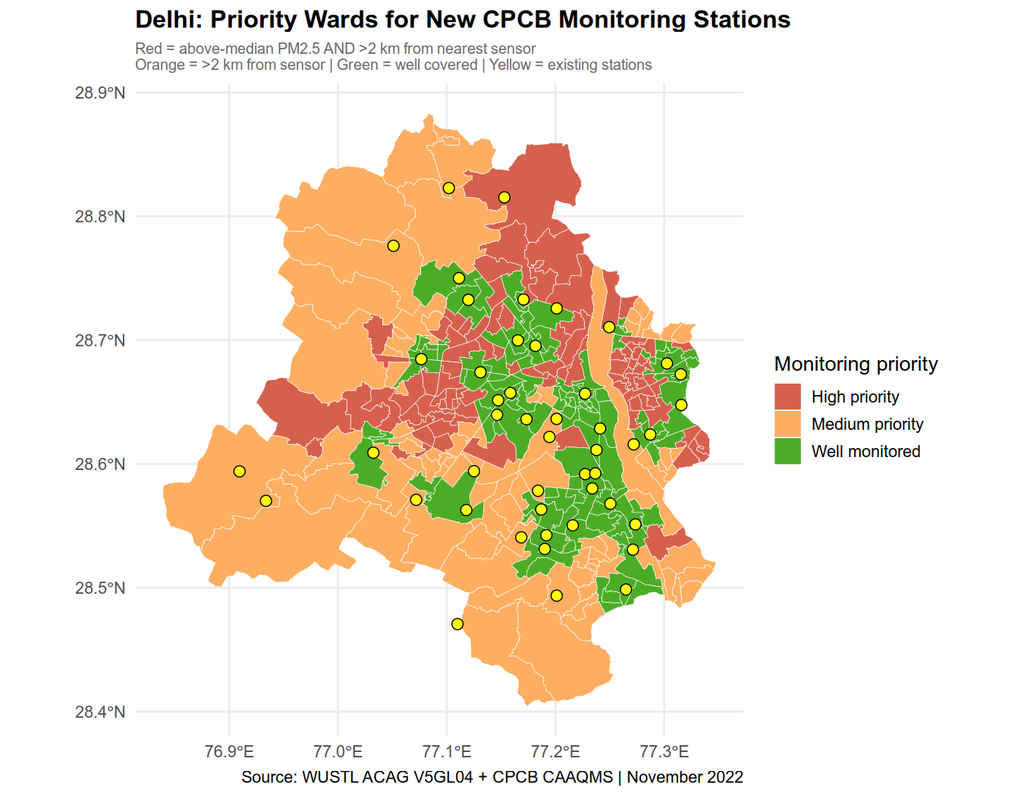

Priority wards for new CPCB stations. Red = high pollution AND poor sensor coverage (>2 km from nearest station). Orange = poor coverage only. Green = well monitored.

```r
ggplot() +
  geom_sf(
    data = delhi_wards, aes(fill = priority),
    color = "white", linewidth = 0.15
  ) +
  geom_sf(
    data  = delhi_full_sf,
    color = "black", fill = "yellow",
    size  = 3, shape = 21
  ) +
  scale_fill_manual(
    values = c(
      "High priority"   = "#d6604d",
      "Medium priority" = "#fdae61",
      "Well monitored"  = "#4dac26"
    ),
    na.value = "grey80",
    name     = "Monitoring priority"
  ) +
  labs(
    title    = "Delhi: Priority Wards for New CPCB Monitoring Stations",
    subtitle = "Red = above-median PM2.5 AND >2 km from nearest sensor\nOrange = >2 km from sensor | Green = well covered | Yellow = existing stations",
    caption  = "Source: WUSTL ACAG V5GL04 + CPCB CAAQMS | November 2022"
  ) +
  xlab(NULL) + ylab(NULL) +
  theme_minimal(base_size = 13) +
  theme(
    text          = element_text(family = "Arial"),
    plot.title    = element_text(face = "bold"),
    plot.subtitle = element_text(size = 9.5, color = "grey40")
  )
```

```r
ggsave(fig_path("fig5_priority_map.png"), width = 9, height = 7, dpi = 300)
```

### Does Sensor Distance Predict Disagreement?

```r
cor_val <- cor(
  delhi_wards$nearest_winter_km,
  abs(delhi_wards$delta),
  use = "complete.obs"
)
cat("Correlation (distance vs |delta|): r =", round(cor_val, 3), "\n")
```

```
#> Correlation (distance vs |delta|): r = 0.153
```

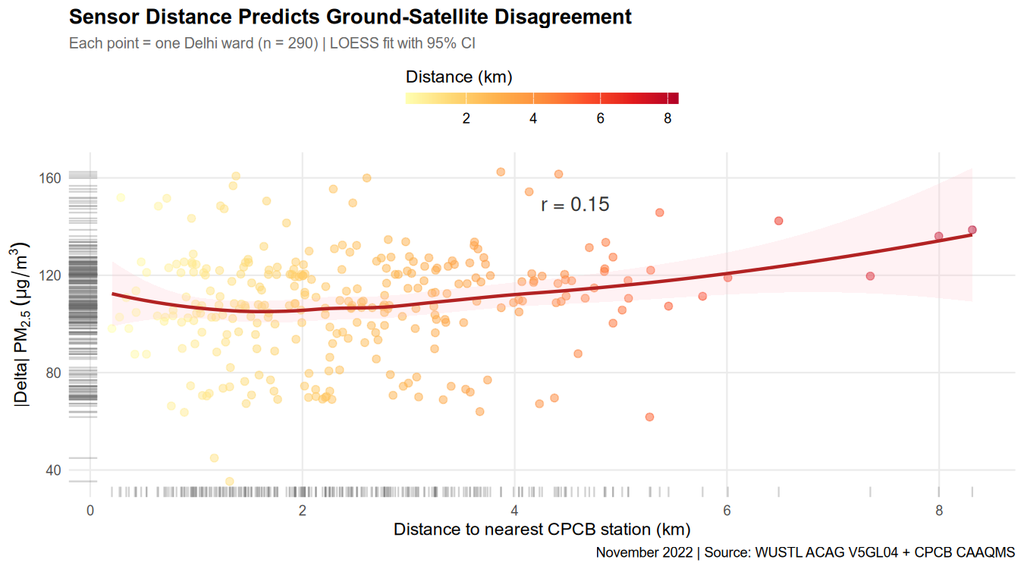

Relationship between sensor distance and ground-satellite disagreement across 290 Delhi wards. LOESS fit with 95% CI captures any non-linear trend.

```r
ggplot(
  data = sf::st_drop_geometry(delhi_wards),
  aes(x = nearest_winter_km, y = abs(delta))
) +
  geom_rug(alpha = 0.3, color = "grey40") +
  geom_point(aes(color = nearest_winter_km), size = 2, alpha = 0.5) +
  geom_smooth(method = "loess", se = TRUE,
              color = "firebrick", fill = "pink", alpha = 0.2) +
  annotate(
    "text",
    x     = max(delhi_wards$nearest_winter_km, na.rm = TRUE) * 0.55,
    y     = max(abs(delhi_wards$delta), na.rm = TRUE) * 0.92,
    label = paste0("r = ", round(cor_val, 2)),
    size  = 4.5, color = "grey20"
  ) +
  scale_color_distiller(
    palette   = "YlOrRd",
    direction = 1,
    name      = "Distance (km)"
  ) +
  labs(
    title    = "Sensor Distance Predicts Ground-Satellite Disagreement",
    subtitle = "Each point = one Delhi ward (n = 290) | LOESS fit with 95% CI",
    x        = "Distance to nearest CPCB station (km)",
    y        = expression(paste("|Delta| PM"[2.5] ~ (mu * g/m^3))),
    caption  = "November 2022 | Source: WUSTL ACAG V5GL04 + CPCB CAAQMS"
  ) +
  theme_minimal(base_size = 11) +
  theme(
    text             = element_text(family = "Arial"),
    legend.position  = "top",
    panel.grid.minor = element_blank(),
    plot.title       = element_text(face = "bold"),
    plot.subtitle    = element_text(size = 9.5, color = "grey40")
  ) +
  guides(color = guide_colorbar(
    barwidth       = unit(12, "lines"),
    barheight      = unit(0.5, "lines"),
    title.position = "top"
  ))
```

```r
ggsave(fig_path("fig6_distance_vs_disagreement.png"), width = 9, height = 5, dpi = 300)
```

# Discussion

## Seasonal Pattern

Ground readings run consistently higher than satellite estimates. This is expected — CPCB stations are often sited near pollution sources to capture worst-case exposure, whereas satellite represents a spatial mean over entire 1 km pixels.

## Monitoring Gap

# Limitations